# Natural Language Processing example: Amazon Fine Food Reviews

## R example: Text cleaning (preprocessing), TF-IDF and hierarchical term clustering

This example is intended to be a counterpart for Python examples in which a process pipeline for classic NLP-based problems is displayed. Here, it is implemented with the most classic solution available for R language: **tm**. This package helps visualize easily the same pipeline we worked on in Python language, without adding complexity in the field of language new structures (such as data pipelines or new type of data frames).

As a counterpart of the examples already analyzed, text preprocessing is constrained to stripping punctuation and removing stopwords (in this case, the list of stopwords is improved to reflect problem particularities). After this preprocessing stage, standard TF-IDF matrix is calculated as a Term-Document matrix (in sparse format to avoid excessive RAM consumption), and finally a clustering algorithm is applied.

Nonetheless, the clustering algorithm here used is applied over terms (and not documents, as before), seeing term relations over documents (this is achieved by transforming Term-Document matrix to Document-Term one by just transposing it). Selection of a reduced set of terms is here performed and then term relations over this reduced set is discovered and plotted.

## Some concerns about it

This approach is very illustrative of how a data pipeline can be directly implemented in R language with little effort and great explicability. Nonetheless, it is a memory-inefficient approach to this problem, and implementations of NLP-based solutions should take this into account, and try other, more modern, approaches to the problem. It is expected to increase memory- and time-efficiency as well as final performance of the solution.

Packages like **tidytext** are very interesting in this direction, but there are many others, which can be accessed in https://cran.r-project.org/web/views/NaturalLanguageProcessing.html (and other related CRAN Task Views).

## Load packages and data

```r
# Clean workspace
rm(list=ls())

# Load package
require(tm)
# Start timing
t1 <- Sys.time()

# Read data
datos <- read.csv2("/home/fernando/Documentos/MBDS/nlp_example/data/amazon-fine-foods/Reviews.csv",
                  header=FALSE,col.names = c('Id','ProductId','UserId',
                                             'ProfileName','HelpfulnessNumerator',
                                             'HelpfulnessDenominator','Score','Time',
                                             'Summary','Text'), skip=1,sep=',',
                  colClasses = c('numeric','character','character','character',
                                 'numeric','numeric','numeric','numeric','character',
                                 'character'))
```

## Text preprocessing

```r
# Build a corpus
datos.corpus <- Corpus(VectorSource(datos$Text))

# Make each letter lowercase
datos.corpus <- tm_map(datos.corpus, tolower)

# Remove punctuation
datos.corpus <- tm_map(datos.corpus, removePunctuation)

# Remove generic and custom stopwords
my_stopwords <- c(stopwords('english'),'br','like','love','food','great','will','can')
datos.corpus <- tm_map(datos.corpus, removeWords, my_stopwords)
```

## TF-IDF

In this example, regular TF-IDF transformation is applied. Nevertheless, it is important to note that by changing weighting function (*TF*, *TF-IDF*, *Binary* and *SMART* transformations are already shipped with **tm** package, but custom weighting fuctions can be implemented or applied via plugins), the content of Term-Document matrix is radically changed, and the data scientist is advised to consider different options (first conceptually, then functionally as part of a solution and finally accounting final performance) at this stage, before applying just one weighting function.

Already shipped weighting functions are:

- *TF*
- *TF-IDF*
- *Binary* weighting: term appears/does not appear in document
- *SMART* weighting: check /home/fernando/R/x86_64-pc-linux-gnu-library/3.3/tm/help/weightSMART after loading **tm** package for more reference.

```r
# Build a term-document matrix
datos.dtm <- TermDocumentMatrix(datos.corpus,
                                control=list(weighting=function(x) weightTfIdf(x)))
# Inspect the document-term matrix
datos.dtm
```

```
## <<TermDocumentMatrix (terms: 239425, documents: 568454)>>
## Non-/sparse entries: 18933670/136083165280
## Sparsity           : 100%
## Maximal term length: 192
## Weighting          : term frequency - inverse document frequency (normalized) (tf-idf)
```

```r
# Inspect most popular words
findFreqTerms(datos.dtm, lowfreq=30)
```

```
##   [1] "appreciates" "better"      "bought"      "canned"      "dog"
##   [6] "finicky"     "found"       "good"        "labrador"    "looks"
##  [11] "meat"        "processed"   "product"     "products"    "quality"
##  [16] "several"     "smells"      "stew"        "vitality"    "actually"
##  [21] "arrived"     "error"       "intended"    "jumbo"       "labeled"
##  [26] "peanuts"     "represent"   "salted"      "sized"       "small"
##  [31] "sure"        "unsalted"    "vendor"      "around"      "brother"
##  [36] "case"        "chewy"       "citrus"      "coated"      "confection"
##  [41] "cut"         "familiar"    "flavorful"   "gelatin"     "heaven"
##  [46] "highly"      "liberally"   "light"       "lion"        "mouthful"
##  [51] "nuts"        "powdered"    "recommend"   "selling"     "sisters"
##  [56] "squares"     "story"       "sugar"       "tiny"        "treat"
##  [61] "yummy"       "addition"    "beer"        "believe"     "cherry"
##  [66] "extract"     "flavor"      "got"         "ingredient"  "looking"
##  [71] "made"        "medicinal"   "ordered"     "root"        "secret"
##  [76] "soda"        "assortment"  "deal"        "delivery"    "lover"
##  [81] "price"       "quick"       "taffy"       "wide"        "bag"
##  [86] "bit"         "brand"       "complaint"   "delightful"  "enjoyable"
##  [91] "etc"         "favorites"   "five"        "flavors"     "grape"
##  [96] "hair"        "husband"     "just"        "kids"        "lasted"
##  [ reached getOption("max.print") -- omitted 9863 entries ]
```

Finally, most relevant terms (those that appear more than *sparse* rate in the corpus) are retained here for analysis. This approach is different from the one applied in Python examples, because the problem we aim to solve is different (clustering terms instead of documents). We finally inspect the reduced dataset to see the final matrix dimensionality, now stored as a dense matrix (all elements are stored in memory) as it is not the full, sparse matrix.

```r
# Remove sparse terms to simplify the cluster plot
# Note: tweak the sparse parameter to determine the number of words.
datos.dtm2 <- removeSparseTerms(datos.dtm, sparse=0.9)

# Convert the sparse term-document matrix to a standard data frame
datos.df <- as.data.frame(as.matrix(datos.dtm2))

# Inspect dimensions of the data frame
nrow(datos.df)
```

```
## [1] 28
```

```r
ncol(datos.df)
```

```
## [1] 568454
```

## Hierarchical clustering

A general purpose clustering algorithm is **hierarchical clustering**. It is based on a distance matrix among all samples to be clustered (in this example, all terms), and it starts merging two samples each step. There are different ways to merge samples, but some of them are specially relevant:

- *Complete-linkage* clustering: merges maximum distance pair of samples.
- *Single-linkage* clustering: merges minimum distance pair of samples
- *Minimum energy* clustering: a criteria for intra-cluster energy is defined, and hierarchical clustering optimizes this measure searching for the global (or reaching a local) minimum.

Other linkage criteria include:

- The sum of all intra-cluster variance.
- The decrease in variance for the cluster being merged (Ward’s criterion).
- The probability that candidate clusters spawn from the same distribution function (V-linkage).
- The product of in-degree and out-degree on a k-nearest-neighbour graph (graph degree linkage).
- The increment of some cluster descriptor (i.e., a quantity defined for measuring the quality of a cluster) after merging two clusters.

In this case, aiming to maintain internal coherence among examples, we will use Ward’s criterion, which is referred to as `ward.D2` in R documentation.

```r
datos.df.scale <- scale(datos.df)
rm(datos,datos.df,datos.dtm,datos.dtm2,datos.corpus,my_stopwords)

# Euclidean distance matrix
concepts <- dist(datos.df.scale, method = "euclidean")
fit <- hclust(concepts, method="ward.D2")
```

## Displaying results in a dendrogram

Once clustering is performed over all terms in the restricted set, it is important to visualize the result. As relations for all pairs are difficult to visualize, there is a simpler, tree-based representation called **dendrogram**. It displays more closely related words as top-down leafs in the tree diagram. Words are added from bottom to top as distance among them increase, and less related words are only linked by top tree node.

This diagram helps the data scientist retrieve information about term relations quickly, as related terms are usually placed near to each other, and non-related terms appear in distant places in the diagram.

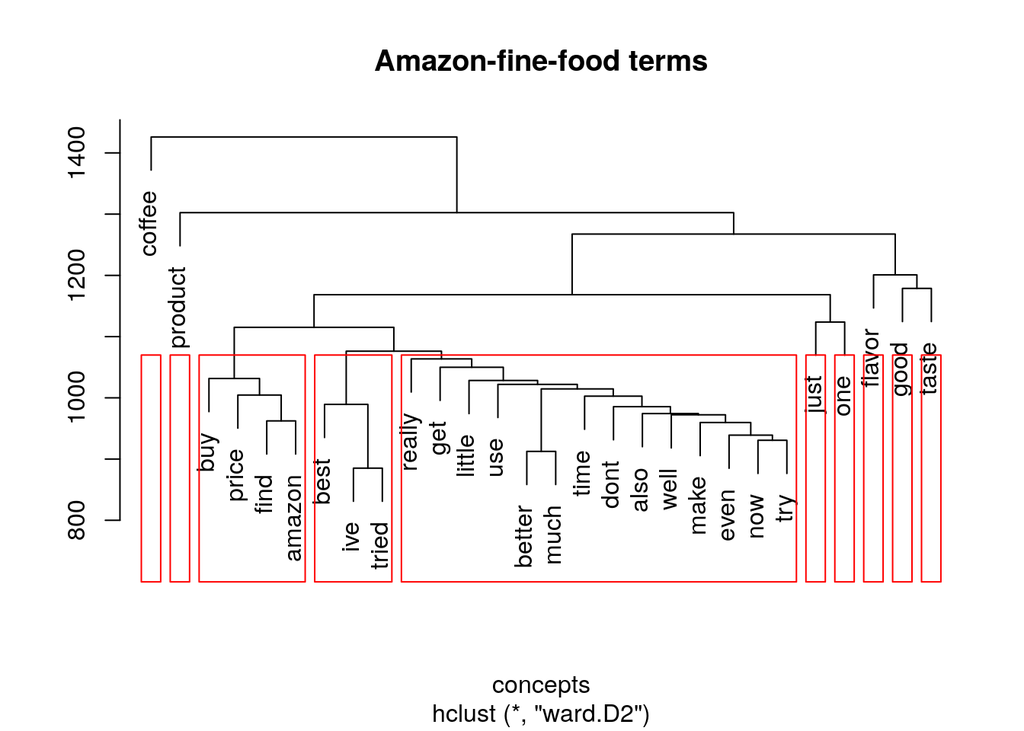

```r
# Display dendrogram
plot(fit,main="Amazon-fine-food terms",ylab="")

# Cut tree into 10 clusters
groups <- cutree(fit, k=10)

# Draw dendogram with red borders around the 10 clusters
rect.hclust(fit, k=10, border="red")
```

```r
# Print total time lapsed
t2 <- Sys.time()
round(t2-t1,1)
```

```
## Time difference of 3.7 mins
```